# 2_finetune a pretrained model

## Exercise 9B using the ArcGIS API for Python

### Import libraries

```python
from arcgis.gis import GIS
from arcgis.learn import prepare_data, MaskRCNN
```

```
2025-01-24 21:31:21.190951: W tensorflow/compiler/tf2tensorrt/utils/py_utils.cc:38] TF-TRT Warning: Could not find TensorRT
```

```python
gis = GIS("home")
```

### Prepare the image chips for training

When using ArcGIS Notebooks in ArcGIS Online you can leverage the `arcgis` directory to store files.

```python
dataPath = r'/arcgis/home/Building Detection/DLTrainingSamples'
```

From the [help documentation](https://developers.arcgis.com/python/latest/api-reference/arcgis.learn.toc.html#prepare-data) for `prepare_data`

> Prepares a data object from training sample exported by the Export Training Data tool in ArcGIS Pro or Image Server, or training samples in the supported dataset formats. This data object consists of training and validation data sets with the specified transformations, chip size, batch size, split percentage, etc.

```python
data = prepare_data(dataPath, batch_size=16, chip_size=112, class_mapping={'1': 'Building'})
```

### Train the MaskRCNN model

From the [help documentation](https://developers.arcgis.com/python/latest/api-reference/arcgis.learn.toc.html#maskrcnn) for `MaskRCNN`

> Model architecture from https://arxiv.org/abs/1703.06870. Creates a MaskRCNN Instance segmentation model, based on https://github.com/pytorch/vision/blob/master/torchvision/models/detection/mask_rcnn.py.

```python
model = MaskRCNN(data, backbone='resnet50')
```

```
Downloading: "https://download.pytorch.org/models/maskrcnn_resnet50_fpn_coco-bf2d0c1e.pth" to /home/arcgis/.cache/torch/hub/checkpoints/maskrcnn_resnet50_fpn_coco-bf2d0c1e.pth
```

Identify the optimized learning rate for the model. From the [help documentation](https://developers.arcgis.com/python/latest/api-reference/arcgis.learn.toc.html#arcgis.learn.MaskRCNN.lr_find) for `model.lr_find()`

> Runs the Learning Rate Finder. Helps in choosing the optimum learning rate for training the model.

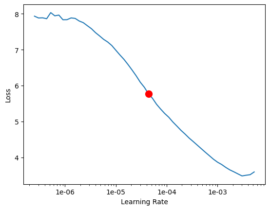

```
4.365158322401661e-05
```

```python
lr = model.lr_find()
lr.real
```

Train the MaskRCNN model. From the [help documentation](https://developers.arcgis.com/python/latest/api-reference/arcgis.learn.toc.html#arcgis.learn.MaskRCNN.fit) for `model.fit()`

> Train the model for the specified number of epochs and using the specified learning rates.

```python
model.fit(epochs=20, lr=lr.real)
```

| epoch | train_loss | valid_loss | average_precision | time |
| --- | --- | --- | --- | --- |
| 0 | 6.063559 | 3.432942 | 0.000000 | 00:57 |
| 1 | 3.839427 | 1.501110 | 0.000000 | 01:09 |
| 2 | 2.606046 | 1.195142 | 0.000000 | 01:12 |
| 3 | 1.921207 | 0.998047 | 0.314345 | 00:48 |
| 4 | 1.470461 | 0.870002 | 0.515599 | 00:59 |
| 5 | 1.187723 | 0.852779 | 0.557375 | 01:01 |
| 6 | 1.009701 | 0.815481 | 0.591315 | 00:59 |
| 7 | 0.886515 | 0.769873 | 0.629500 | 00:49 |
| 8 | 0.809627 | 0.784671 | 0.640286 | 00:59 |
| 9 | 0.741587 | 0.755024 | 0.665391 | 00:58 |
| 10 | 0.702733 | 0.744045 | 0.663648 | 00:52 |
| 11 | 0.661913 | 0.705238 | 0.690689 | 00:53 |
| 12 | 0.647970 | 0.709542 | 0.669625 | 00:58 |
| 13 | 0.631397 | 0.713381 | 0.691388 | 00:58 |
| 14 | 0.627581 | 0.711223 | 0.684226 | 00:48 |
| 15 | 0.615900 | 0.691797 | 0.662992 | 00:57 |
| 16 | 0.600323 | 0.703278 | 0.685417 | 00:57 |
| 17 | 0.601112 | 0.691429 | 0.676427 | 00:58 |
| 18 | 0.602382 | 0.694853 | 0.681529 | 00:44 |
| 19 | 0.595687 | 0.696011 | 0.681529 | 00:58 |

Plot the training and validation loss curves. From the [help documentation](https://developers.arcgis.com/python/latest/api-reference/arcgis.learn.toc.html#arcgis.learn.MaskRCNN.plot_losses) for `model.plot_losses()`

> Plot validation and training losses after fitting the model.

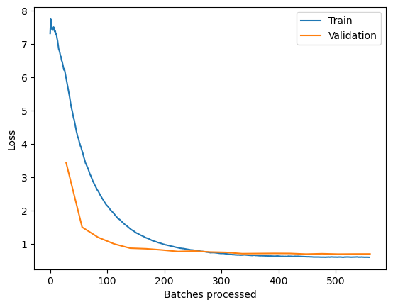

```python
model.plot_losses()
```

From the [help documentation](https://developers.arcgis.com/python/latest/api-reference/arcgis.learn.toc.html#arcgis.learn.MaskRCNN.average_precision_score)

> Computes average precision on the validation set for each class.

```python
model.average_precision_score()
```

100.00% [4/4 00:08<00:00]

```
{'Building': 0.6764273575721608}
```